# Lesson 3: Data Wrangling Basics

Ashir Borah and Natalie Elphick

October 28th, 2024

Press the “?” key for tips on navigating these slides

## Outline

- Working in Rstudio with notebooks
- Loading and inspecting data
- Working with vectors
- Working with matrices
- Working with dataframes (the old fashioned way)

# R and Rstudio

[figure not shown]

## Different ways to work with R

- Enter commands directly into the console
- Write ‘scripts’: set of R code to execute as a unit (.R files)
- Write ‘packages’: sets of functions that others can use
- **Write analysis ‘notebooks’** (R markdown: .Rmd files)
  - Easily share results and methods in different formats
  - Encourages good code and analysis practices

## Rstudio: Live demo

- Different components of Rstudio interface
- Running code lines
- Running code chunks
- Creating new chunks
- Creating, inspecting and clearing variables
- There are many good Rstudio video tutorials, e.g.: (https://youtu.be/kfcX5DEMAp4)

## Make your code readable!

- **Why?**
  - Others can understand what you’ve done (including future you)
  - Reproducibility and open science
  - Clarify your logical thought process while writing code
- **How?**
  - Write descriptive text before each code chunk in R notebooks:
    - Describe data used, analysis approach
    - What are you trying to test/show with a given analysis?

## Comments

Also good to include comments in your code for specifics/lightweight explanation

- R ignores stuff after `#`

```r
#add a fixed offset to avoid negative values
new_data <- old_data + offset

#now normalize so max value is 1
new_data <- new_data/max(new_data)
```

```r
new_data <- my_pipeline_function(new_data, outliers = 'ignore') #drop 6-sigma outliers
```

## Create project directory

- Organize your work as ‘Projects’ in Rstudio
- Each project has a separate folder, with data, code, results.
- You will practice setting up a new project for today’s assignment.

# Loading data

## Basics of data formats

- Small-scale data are typically stored as text files
- Different ‘rows’ of data appear on different lines
- Values for a given ‘row’ are typically separated by either a comma, or a tab

## Comma-separated values (.csv)

```
name,age,member_since
bob,20,2015
frank,40,2015
tammy,15,2016
```

## Tab-separated values (.tsv or .txt)

```
name  age  member_since
bob  20  2015
frank  40  2015
tammy  15  2016
```

## A zoo of data loading functions

| Data type | Extension | Function | Package |
| --- | --- | --- | --- |
| Comma separated values | csv | `read.csv()` | utils (default) |
|  |  | `read_csv()` | readr (tidyverse) |
| Tab separated values | tsv | `read_tsv()` | readr |
| Other delimited formats | txt | `read.table()` | utils |
|  |  | `read_table()` | readr |
|  |  | `read_delim()` | readr |
| Excel | xlsx, xls | `read_excel()` | readxl (tidyverse) |

## Practical advice on data loading

- For loading data tables, we suggest:
  - Use `read_delim` (part of the `tidyverse` megapackage) for text files (.csv, .tsv, .txt)
  - Use `read_excel` for loading .xls, .xlsx files
- We’ll discuss more about loading data matrices later.
- For example:

```r
my_table <- read_delim('my_data_file.csv')
```

## Specifying where a file ‘is’

File locations (‘paths’) can be specified in absolute or relative terms

- An ‘absolute’ path specifies where exactly in your computer’s ‘directory structure’ a given file lives
- For example:

```r
imported_data <- read_csv("/Users/jmmcfarl/BootCamp/cp_r_bootcamp/
                          data/data_file.csv")
```

- `data_file.csv` lives inside `data` folder, inside `cp_r_boocamp`, etc.
- But these will vary from computer to computer, so makes code sharing harder..

## Relative paths

This will look for the file inside your ‘working directory’

```r
imported_data <- read_csv('data_file.csv')
```

What’s the working directory and how does it get set?

## To avoid having to worry about this

- Organize project-specific data in a ‘data’ subfolder and use Rstudio projects
- Use the `here` function from the `here` package to find the right relative path within the project.

```r
library(here)
here('data', 'my_data_file.csv')
```

```
[1] "data/my_data_file.csv"
```

You can use it like this:

```r
imported_csv <- read_delim(here('data', 'data_file.csv'))
imported_tsv <- read_delim(here('data', 'tab_separated_table.tsv'))
```

## Loading from Excel sheets

Load the second sheet from an xlsx file

```r
my_table <- read_excel(here('data', 'my_metadata_file.xlsx'), sheet = 2)
```

Uses the `readxl` package part of `tidyverse`

## Loading matrices

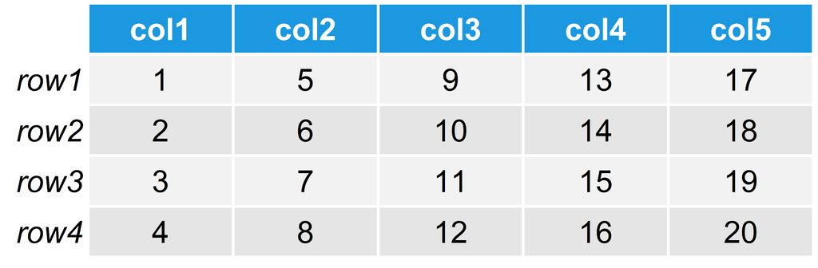

- The size of matrices is often too large for `read_delim` to work well.
- The first column is special: ‘row names’

## Loading matrices

- Let’s use `fread` from the `data.table` package
- `fread` creates a slightly different type of table than we want. `as_tibble` converts to the right kind.

```r
library(data.table)
counts_matrix <-  fread(here('data', 'counts_rpkm.csv'))
counts_matrix <- as_tibble(counts_matrix) #convert to a 'tibble'
corner(counts_matrix)
```

```
# A tibble: 5 × 5
  Gene               sample2 sample5 sample7 sample8
  <chr>                <dbl>   <dbl>   <dbl>   <dbl>
1 ENSMUSG00000000001 19.3    23.7       2.61  5.85
2 ENSMUSG00000000003  0       0         0     0
3 ENSMUSG00000000028  1.03    0.827     1.13  0.699
4 ENSMUSG00000000031  0       0         0     0.0298
5 ENSMUSG00000000037  0.0560  0.0473    0     0.0686
```

## Loading matrices

Then we want to make one of the column rownames and mint our new data matrix

```r
counts_matrix <- column_to_rownames(counts_matrix, var = 'Gene') #set Gene column to rownames
counts_matrix <- as.matrix(counts_matrix) #formally make it a matrix, not really necessary
corner(counts_matrix)
```

```
                     sample2    sample5 sample7   sample8   sample9
ENSMUSG00000000001 19.265000 23.7222000 2.61161 5.8495400 6.5126300
ENSMUSG00000000003  0.000000  0.0000000 0.00000 0.0000000 0.0000000
ENSMUSG00000000028  1.032290  0.8269540 1.13441 0.6987540 0.9251170
ENSMUSG00000000031  0.000000  0.0000000 0.00000 0.0298449 0.0597726
ENSMUSG00000000037  0.056033  0.0473238 0.00000 0.0685938 0.0494147
```

## Inspecting data

- Always start with some quick inspection of data after reading it into R
- Check for:
  - Column (always) and row (matrix only) names are correct
  - Make sure data types of columns are correct
- Useful inspection functions:
  - `View(df)`: Open spreadsheet viewer
  - `head(df)`: Show top K (10) rows
  - `glimpse(df)`: quick overview of a table
  - `useful::corner(mat)`: Show upper left corner of matrix
  - `dim(mat)`: Number of rows and columns
  - `rownames(mat)`/`colnames(mat)`: extract row/column names

## Backup plan

- If you’re having trouble with the above data loading strategies
- Or you want to load a data file that’s not part of your local project directory (and don’t want to bother with file paths)
- You can import files using the RStudio `Import Dataset` tool (see [here](https://support.rstudio.com/hc/en-us/articles/218611977-Importing-Data-with-the-RStudio-IDE) for more info).

# Working with data in R

## 3 ways to access data

- By position
- By logical conditions
- By name

## Selecting by position

```r
age <- c(15, 22, 45, 52, 73, 81)
```

```r
age[5]
```

```
[1] 73
```

```r
idx <- c(3,5,6) # create vector of the elements of interest
age[idx]
```

```
[1] 45 73 81
```

## Selecting elements with logical statements

| Operator | Description |
| --- | --- |
| > | greater than |
| >= | greater than or equal to |
| < | less than |
| <= | less than or equal to |
| == | equal to |
| != | not equal to |
| & | and |
| \| | or |

```r
age > 50
```

```
[1] FALSE FALSE FALSE  TRUE  TRUE  TRUE
```

```r
log_idx <- age > 50
age[log_idx]
```

```
[1] 52 73 81
```

```r
#same as age[age > 50]
```

```r
age == 52
```

```
[1] FALSE FALSE FALSE  TRUE FALSE FALSE
```

```r
age[age == 52]
```

```
[1] 52
```

```r
age[age != 52]
```

```
[1] 15 22 45 73 81
```

## Subsetting using names

Can assign names to each element in a vector

```r
age <- c(Allice = 15, Bob = 22, Charlie = 45, Dan = 52)
age
```

```
 Allice     Bob Charlie     Dan
     15      22      45      52
```

```r
names(age)
```

```
[1] "Allice"  "Bob"     "Charlie" "Dan"
```

Can also set names on a given vector

```r
age <- c(15, 22, 45, 52)
names(age) <- c('Allice', 'Bob', 'Charlie', 'Dan')
```

## Subsetting using names

```r
age
```

```
 Allice     Bob Charlie     Dan
     15      22      45      52
```

Selecting elements by name is generally unambiguous

```r
age[c('Bob', 'Charlie')]
```

```
    Bob Charlie
     22      45
```

- Vectors often are unnamed.
- Most useful when working with lists (more to come)

## Brief asside on NULL

R has another special value `NULL` which represents ‘the absence of a value’.

For example

```r
my_vec <- c(1,2,3)
names(my_vec)
```

[output not shown]

Note: Subtly different from `NA`, but don’t worry about that now.

## Reordering data

```r
x <- c(4, 2, 3, 5, 1)
sort(x)
```

```
[1] 1 2 3 4 5
```

- Or in decreasing order

```r
sort(x, decreasing = TRUE)
```

```
[1] 5 4 3 2 1
```

## Reordering using indexing

Indexing can also be used to reorder data

```r
teaching_team <- c("Mary", "Meeta", "Radhika")
```

```r
reorder_teach <- teaching_team[c(3, 1, 2)] # Saving the results to a variable
reorder_teach
```

```
[1] "Radhika" "Mary"    "Meeta"
```

## Subsetting matrices

- Same as subsetting vectors, but can be applied to both rows and columns!
- General formula:

```r
matrix[row_set, column_set]
```

- `row_set` and `column_set` can be individual elements or vectors
- Leave either blank if you want all rows/columns, e.g.:

```r
matrix[row_set, ] #keeps all columns

matrix[, column_set] #keeps all rows
```

## Matrix subsetting examples

```r
useful::corner(counts_mat)
```

```
                     sample2    sample5 sample7   sample8   sample9
ENSMUSG00000000001 19.265000 23.7222000 2.61161 5.8495400 6.5126300
ENSMUSG00000000003  0.000000  0.0000000 0.00000 0.0000000 0.0000000
ENSMUSG00000000028  1.032290  0.8269540 1.13441 0.6987540 0.9251170
ENSMUSG00000000031  0.000000  0.0000000 0.00000 0.0298449 0.0597726
ENSMUSG00000000037  0.056033  0.0473238 0.00000 0.0685938 0.0494147
```

- ‘Slice’ out the third row

```r
counts_mat[3, ]
```

```
 sample2  sample5  sample7  sample8  sample9  sample4  sample6 sample12
1.032290 0.826954 1.134410 0.698754 0.925117 0.827891 1.168630 0.673563
 sample3 sample11 sample10  sample1
0.892183 0.975327 1.045920 0.937792
```

## Matrix subsetting examples

- Or slice out the third column

```r
counts_mat[, 3]
```

[output not shown]

[output cut: 19359 more lines]

[output not shown]

## Matrix subsetting examples

- Slice a set of rows and set of columns

```r
counts_mat[1:4, 2:3]
```

```
                     sample5 sample7
ENSMUSG00000000001 23.722200 2.61161
ENSMUSG00000000003  0.000000 0.00000
ENSMUSG00000000028  0.826954 1.13441
ENSMUSG00000000031  0.000000 0.00000
```

## Using rownames and column names

- Use `colnames(mat)` and `rownames(mat)` to get/set the column and row names of a matrix.
- Data for a specified set of rows (genes)

```r
counts_mat[c('ENSMUSG00000000028', 'ENSMUSG00000000037'), ]
```

```
                    sample2   sample5 sample7   sample8   sample9  sample4
ENSMUSG00000000028 1.032290 0.8269540 1.13441 0.6987540 0.9251170 0.827891
ENSMUSG00000000037 0.056033 0.0473238 0.00000 0.0685938 0.0494147 0.180883
                    sample6  sample12  sample3  sample11 sample10  sample1
ENSMUSG00000000028 1.168630 0.6735630 0.892183 0.9753270 1.045920 0.937792
ENSMUSG00000000037 0.143884 0.0662324 0.146196 0.0206405 0.017004 0.151417
```

- Specifying columns and rows by name

```r
counts_mat['ENSMUSG00000000001', c('sample7', 'sample5')]
```

```
 sample7  sample5
 2.61161 23.72220
```

## The %in% operator

- Check whether each element of vector1 is contained in the set vector2

```r
A <- c(1, 2, 3, 4)
B <- c(3, 4, 5, 6)

A %in% B
```

```
[1] FALSE FALSE  TRUE  TRUE
```

## Applications of %in%

Useful for restricting to the intersection of elements in two lists

```r
A <- c(1, 2, 3, 4)
B <- c(3, 4, 5, 6)

A[A %in% B]
```

```
[1] 3 4
```

Or checking whether any/all elements of A are contained in B

```r
any(A %in% B)
```

```
[1] TRUE
```

```r
all(A %in% B)
```

```
[1] FALSE
```

## Other ‘set’ functions

- `intersect(A, B)`: return the elements in both `A` and `B`
- `setdiff(A, B)`: return the elements in `A` that are not in `B`
- `union(A, B)`: return the elements in either `A` or `B`

## Inspecting data visually

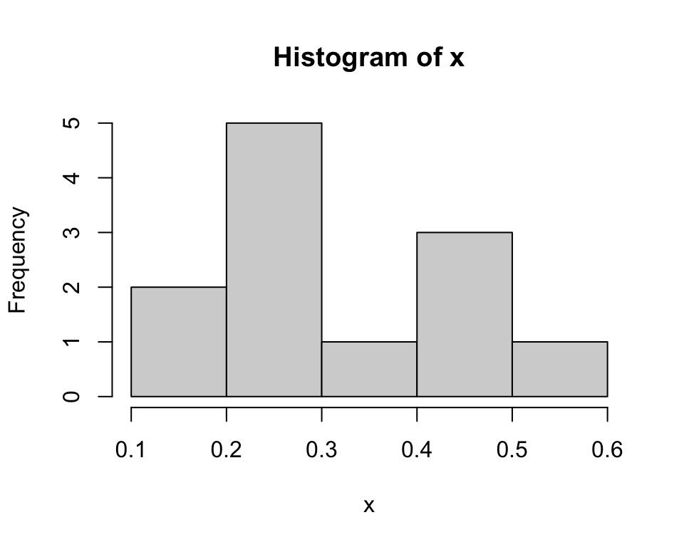

```r
x <- counts_mat['ENSMUSG00000081010',]
hist(x)
```

## Inspecting data visually

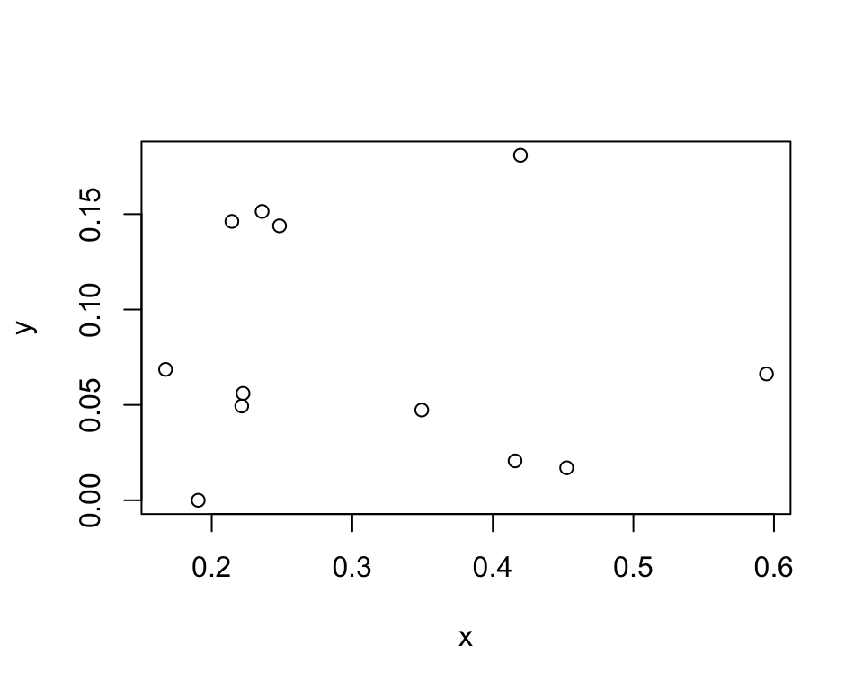

```r
x <- counts_mat['ENSMUSG00000081010',]
y <- counts_mat['ENSMUSG00000000037',]
plot(x,y)
```

## Subsetting lists

A list of lists

```r
people <- list(
  Allice = list(age = 20, height = 50, school = 'MIT'),
  Bob = list(age = 10, height = 30, school = 'Harvard'),
  Charlie = list(age = 40, height = 60, school = 'BU'),
  Frank = c(age = 10, height = 2)
  )
```

- To select a specific element from the list use ‘double brackets’

```r
people[[2]]
```

```
$age
[1] 10

$height
[1] 30

$school
[1] "Harvard"
```

## Subsetting lists

With lists it’s especially useful to access elements by name

```r
people[['Bob']]
```

```
$age
[1] 10

$height
[1] 30

$school
[1] "Harvard"
```

Another (equivalent) way is to use the `$` symbol. This is nice because it works with ‘tab-complete’

```r
people$Bob
```

## Nested indexing of lists

- You can use multiple indices to pull out specific elements nested within a list

```r
people[['Allice']][['school']]
```

```
[1] "MIT"
```

- Using `$` makes it easier to read

```r
people$Allice$height
```

```
[1] 50
```

## Creating dataframes

```r
species <- c("ecoli", "human", "corn")
glengths <- c(4.6, 3000, 50000)
```

- Create a tibble (dataframe, table) using `tibble()` function.
- Input as many columns as you want (must have same length)

```r
df <- tibble(species, glengths)
df
```

```
# A tibble: 3 × 2
  species glengths
  <chr>      <dbl>
1 ecoli        4.6
2 human     3000
3 corn     50000
```

## Creating dataframes

You can name the columns

```r
df <- tibble(animal_species = species, genome_lengths = glengths)
df
```

```
# A tibble: 3 × 2
  animal_species genome_lengths
  <chr>                   <dbl>
1 ecoli                     4.6
2 human                  3000
3 corn                  50000
```

## Quick note on new/old ways

- `data.frame()` is the old way, gives a similar table

```r
df <- data.frame(species = species, glengths = glengths)
df
```

```
  species glengths
1   ecoli      4.6
2   human   3000.0
3    corn  50000.0
```

- But it makes strings into ‘factors’, and has some other subtle differences.
- Use `tibble()` to avoid some rare but confusing issues
- Sometimes we’ll use the terms ‘dataframe’, ‘tibble’, and ‘table’ interchangeably though.

## Extracting a single column

You can access a column from a tibble as if it were a list of vectors (it is):

```r
df$species
```

```
[1] "ecoli" "human" "corn"
```

```r
df[['species']]
```

```
[1] "ecoli" "human" "corn"
```

## Subsetting dataframes

You can access rows and columns of dataframes like matrix indexing

```r
df[2,]
```

[output not shown]

```r
df[2:3, 'glengths']
```

[output not shown]

## Saving data to a file

- Just like the inverse of reading data
- `write_csv` to save tables
- `write.csv` to save matrices (keeps row names)
- Use `here` function to specify the path to save the file

```r
write_csv(df, here('results', 'my_dataframe.csv'))
```

# Key concepts recap

- Reading data in R is kinda of a mess, but stick with `read_delim` for tables, `read_excel` for Excel files, and `data.table::fread` for matrices
- You can extract data from a vector by numeric index, name, or using logical conditions
- Matrices and data frames are the same, you just specify which rows and columns
- Lists are a bit weird, but use `$` to pull out elements by name